# State Frequencies: Marimekko and Bar Plots

The question this tutorial answers: *how do the relative frequencies of states differ across groups?* `plot_state_frequencies()` is the package’s native generic for this pattern. It dispatches across `netobject`, `netobject_group`, `mcml`, and `htna`. The rendering is class-aware:

- For `mcml` and `htna`, the state set in each group/cluster is typically disjoint (different clusters carry different states; AI uses different actions than Human). The default is a per-facet layout: each panel is a stand-alone treemap with its **own** legend showing only that panel’s states, all panels arranged side-by-side.
- For a single `netobject` (no groups) or a `netobject_group` (where groups share the same state set), the default is a single-chart layout with one shared legend at the bottom. Each group still gets its own treemap panel; only the legend is shared.

Both layouts use the colorblind-safe Okabe-Ito palette.

```r
library(Nestimate)
```

## A single network

A single `netobject` has no groups, so the chart is a single squarified treemap: each state becomes a rectangle whose area is exactly proportional to its overall share.

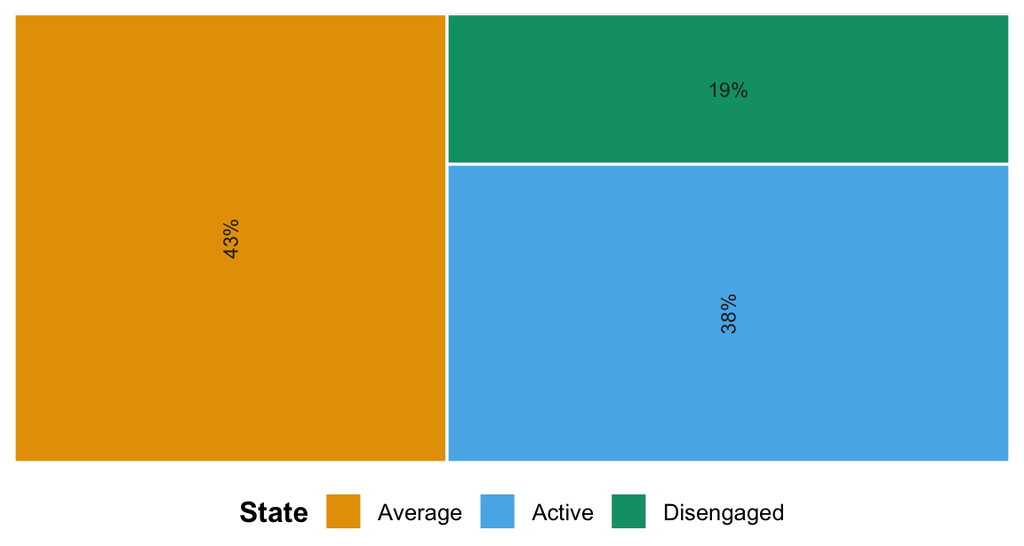

```r
data(trajectories, package = "Nestimate")
nw <- build_network(as.data.frame(trajectories),
                    method = "relative", format = "wide")

plot_state_frequencies(nw)
```

The inline tile labels are controlled via `label`. The default is `"prop"` (proportions). To show raw counts instead, set `label = "freq"`; for both, set `label = "both"`; to suppress inline labels entirely, `label = "none"`.

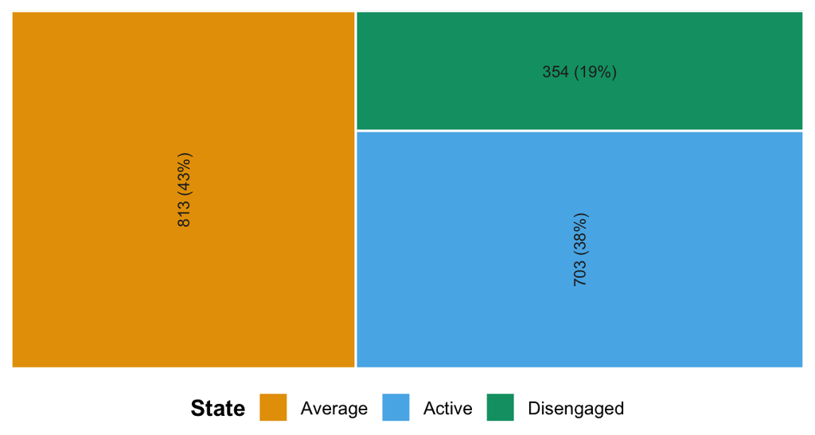

```r
plot_state_frequencies(nw, label = "both")
```

The bar style produces horizontal bars sorted by frequency:

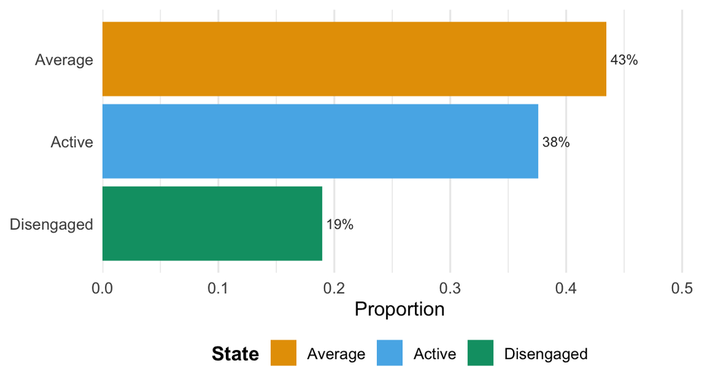

```r
plot_state_frequencies(nw, style = "bars")
```

For bars, `metric` controls whether the bar length encodes the proportion (default) or the raw count:

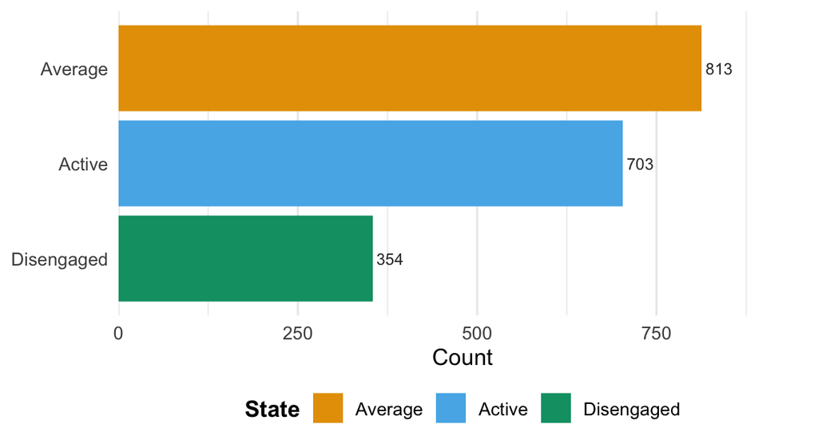

```r
plot_state_frequencies(nw, style = "bars", metric = "freq",
                       label = "freq")
```

## Per-group networks (faceted treemaps)

`build_network()` called with `group =` returns a `netobject_group`. Each group becomes its own treemap panel — the within-group state mix is read directly from tile areas.

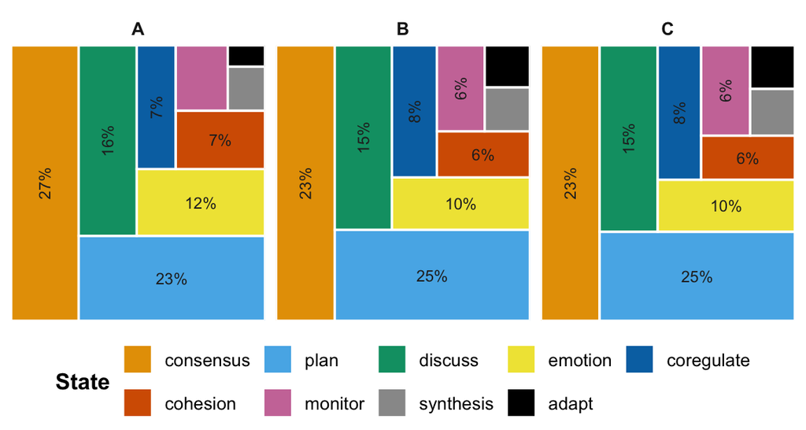

```r
data(group_regulation_long, package = "Nestimate")
nw_g <- build_network(group_regulation_long,
                      method = "relative", format = "long",
                      actor = "Actor", action = "Action",
                      order = "Time", group = "Course")

plot_state_frequencies(nw_g)
```

Three panels, one per course. Each panel is a squarified treemap of that course’s action distribution: the largest tile is the most-frequent action in that course. Cross-panel comparison is by which colored tile dominates each panel.

The bar style switches to horizontal bars, faceted by group:

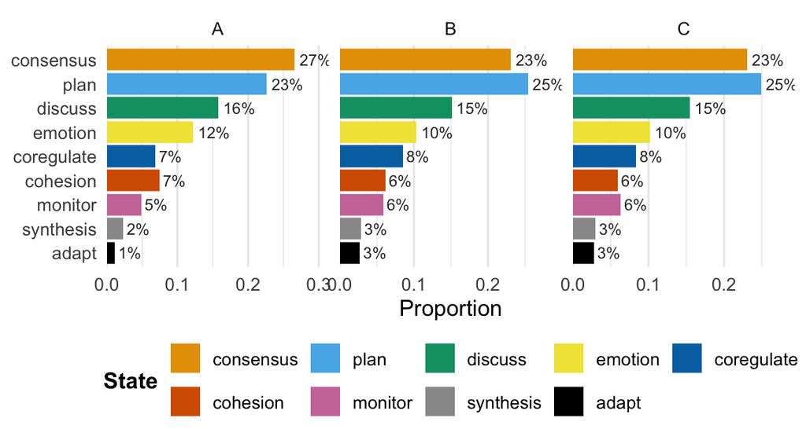

```r
plot_state_frequencies(nw_g, style = "bars")
```

## Multi-cluster multi-level (MCML)

`build_mcml()` partitions the state set into clusters. Because the state vocabularies in different clusters are typically disjoint, the default is a per-cluster layout: each cluster becomes its own treemap panel with its own legend listing only that cluster’s states.

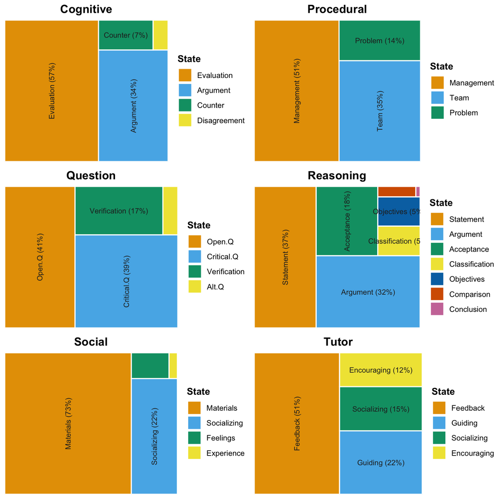

```r
Interactions <- rio::import(
  "/Users/mohammedsaqr/Downloads/mcml_code/Mcdata/complicated_nw2.csv"
)
Nodesin <- rio::import(
  "/Users/mohammedsaqr/Downloads/mcml_code/Mcdata/Codemapping.xlsx"
)

clusters_list <- split(Nodesin$name, Nodesin$groups)
labels_df     <- Nodesin[, c("name", "Code")]

mc <- build_mcml(
  Interactions,
  clusters = clusters_list,
  actor    = "course_group",
  time     = "timestamp",
  action   = "From",
  type     = "tna",
  labels   = labels_df
)
plot_state_frequencies(mc, label = "all", ncol = 2)
```

One stand-alone treemap per cluster, each with its own legend listing only that cluster’s codes. Each panel restarts the palette from the first color, so within-cluster ordering is read by tile size; cross- panel comparison is by cluster width and within-cluster spread.

## Heterogeneous networks (htna)

An `htna` object carries a node-level grouping (`$node_groups`) that labels each state by an actor or context. Each group becomes its own marimekko panel.

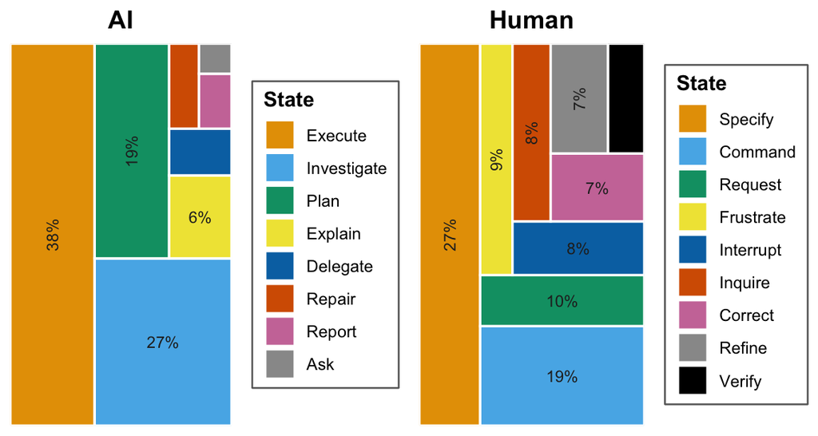

```r
library(htna)
data(ai_long, package = "Nestimate")
data(human_long, package = "Nestimate")

ht <- build_htna(list(AI = ai_long, Human = human_long),
                 action = "code", session = "session_id",
                 order = "code_order")

plot_state_frequencies(ht)
```

## The `plot_mosaic()` primitive

The hierarchical-marimekko geometry is also exposed as a low-level primitive. Any tidy `data.frame(group, state, weight)` works:

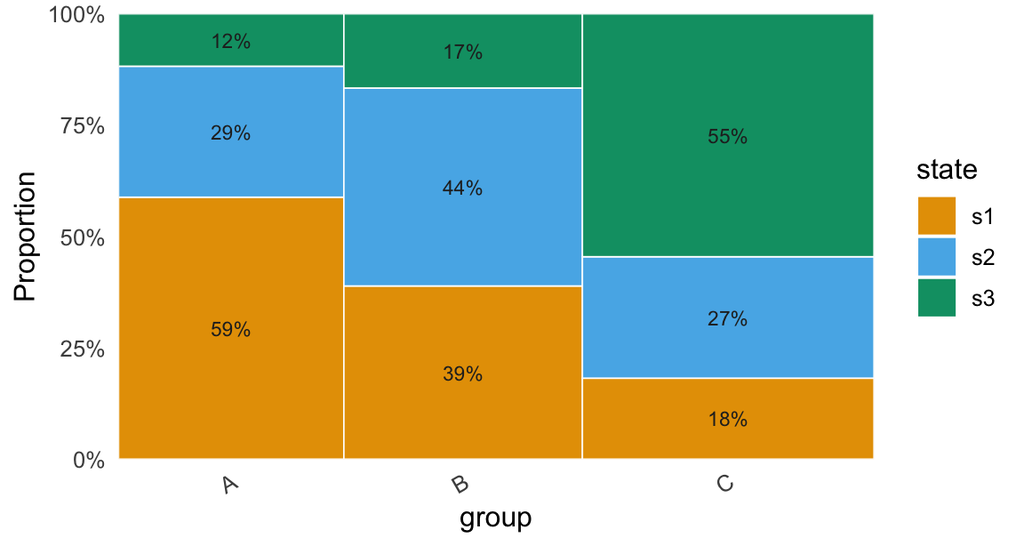

```r
df <- data.frame(
  group  = rep(c("A", "B", "C"), each = 3),
  state  = rep(c("s1", "s2", "s3"), 3),
  count  = c(10, 5, 2,  7, 8, 3,  4, 6, 12)
)
plot_mosaic(df, x = "group", y = "state", weight = "count")
```

The `fill` argument can map to any other column when residual or effect-size shading is wanted instead of state colors. This makes `plot_mosaic()` reusable for residual-style mosaic plots downstream (for example, in permutation-test visualisations).

## Label and legend combinations

Three arguments control all annotation:

- `label` — text inside each tile/bar. `"prop"` (default), `"freq"`, `"both"`, `"state"`, `"all"`, `"none"`.
- `legend` — where the state legend sits. `"bottom"` (default), `"top"`, `"right"`, `"left"`, `"none"`.
- `legend_frame` — `"none"` (default) or `"border"` for an enclosed legend.

Below: a gallery on the same `netobject_group` showing each combination.

### Default (proportions, legend at bottom)

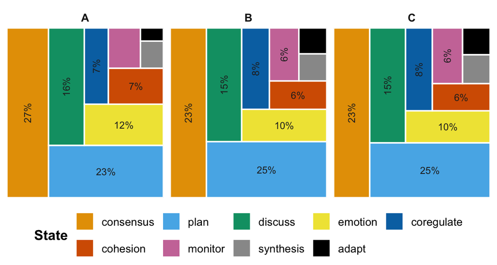

```r
plot_state_frequencies(nw_g)
```

Tile size = state share; percentage labels on the top tiles; legend names the colors at the bottom. The same state always lands in the same relative position across facets, so cross-panel comparison is by *size of the same colored tile*.

### Counts in tiles, legend at right (vertical)

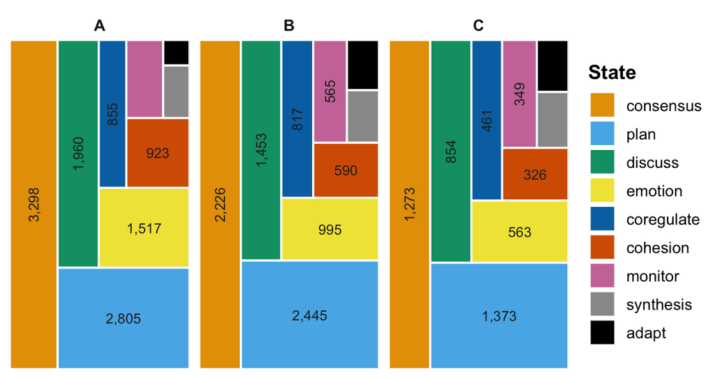

```r
plot_state_frequencies(nw_g, label = "freq", legend = "right")
```

Right-side legend saves vertical space; useful when the figure is tall.

### Both numbers, legend at right with border

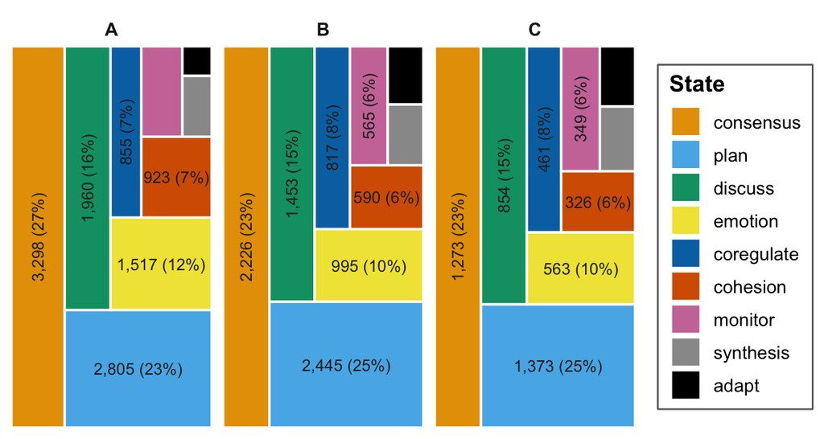

```r
plot_state_frequencies(nw_g, label = "both", legend = "right",
                       legend_frame = "border")
```

`"1,234 (66%)"` inline on each tile; legend enclosed in a thin rectangle (`legend_frame = "border"`) so it reads as a single boxed unit beside the cards.

### Both numbers, no legend

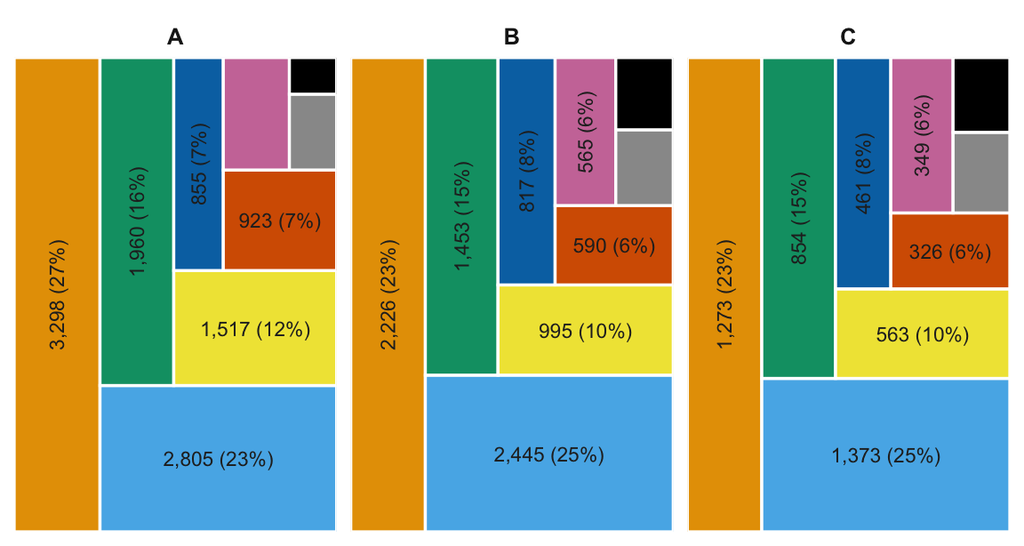

```r
plot_state_frequencies(nw_g, label = "both", legend = "none")
```

Counts + proportions inline, legend hidden because the tiles already carry both numbers. Color is decorative here.

### State names in tiles, no legend (handout style)

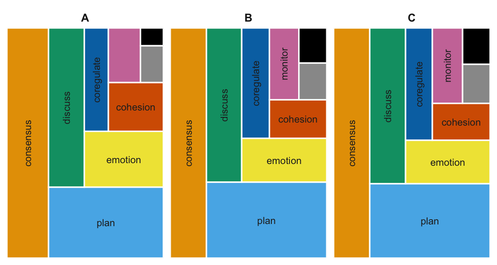

```r
plot_state_frequencies(nw_g, label = "state", legend = "none")
```

State names written directly on the tiles, no separate legend. Useful for printable handouts. Small tiles drop their labels automatically; tile text auto-rotates 90 degrees in tall-narrow tiles to follow the tile’s long axis.

### State name + proportion inline, framed legend

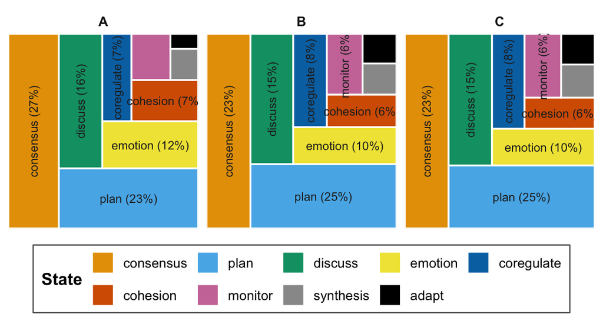

```r
plot_state_frequencies(nw_g, label = "all", legend_frame = "border")
```

### Legend on top, horizontal

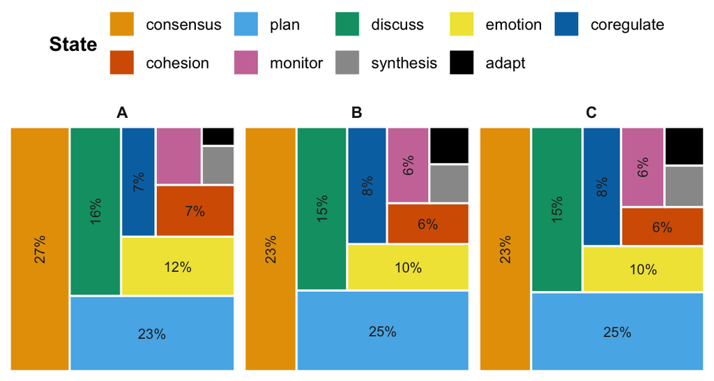

```r
plot_state_frequencies(nw_g, legend = "top")
```

Caption-style legend above the cards. Good for slide layouts where the chart needs to anchor to the bottom of the frame.

### Legend on left, framed

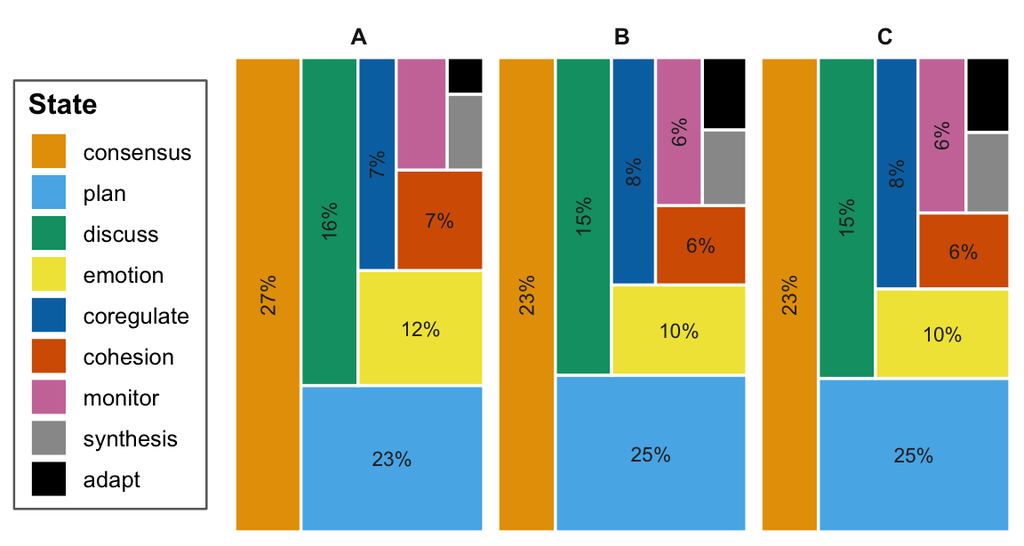

```r
plot_state_frequencies(nw_g, legend = "left", legend_frame = "border")
```

Vertical legend on the left side, framed — mirrors the right-side boxed pattern.

### Frequencies only, no labels in tiles

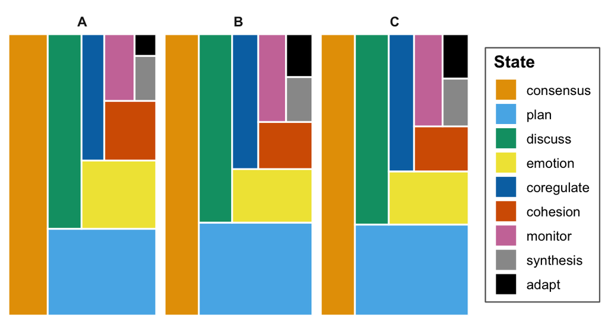

```r
plot_state_frequencies(nw_g, label = "none", legend = "right",
                       legend_frame = "border")
```

Pure tile-area encoding: no inline text at all, only color, with a boxed right-side legend acting as the legend card.

## Label/legend on the htna treemap

[figure not shown]

```r
plot_state_frequencies(ht, label = "all", legend = "right",
                       legend_frame = "border")
```

State names + proportions written inline on each actor’s tiles, with a framed right-side legend providing the color key.

## Per-facet legends

### htna with per-actor legends

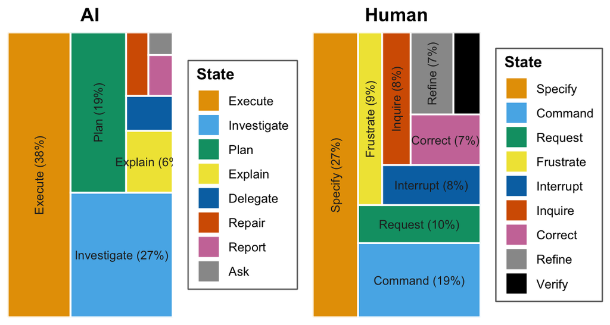

```r
plot_state_frequencies(ht, legend = "per_facet", label = "all")
```

Two panels, AI on the left and Human on the right, each with its own legend showing only that actor’s actions. Enclosed-square legend by default for this mode.

### mcml with per-cluster legends

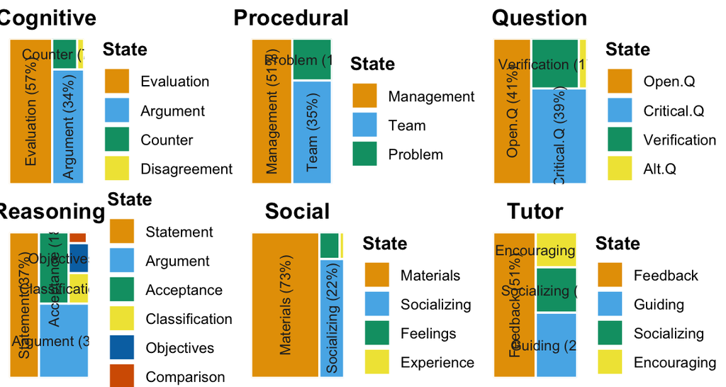

```r
plot_state_frequencies(mc, legend = "per_facet", label = "all")
```

Each cluster becomes a stand-alone treemap with a per-cluster legend. Useful when the cluster state sets are very different.

### netobject_group with per-group legends

[figure not shown]

```r
plot_state_frequencies(nw_g, legend = "per_facet", label = "all")
```

For groups that share the same state set (every course has every action), the per-facet legends will repeat the same set of states. In that case a single shared legend (the default) reads cleaner. Per- facet really shines when the state vocabularies differ across panels.

## Standardized-residual mosaic

`style = "mosaic"` answers a different question: *which states are over- or under-represented in each group, relative to the marginal distribution?* The chart is a state x group contingency table where:

- Row heights are proportional to the state’s total frequency across all groups
- Column widths are proportional to the group’s total count
- Each cell is colored by its **standardized residual** $r_{ij} = (O_{ij} - E_{ij}) / \sqrt{E_{ij}\,(1 - p_{i\cdot})(1 - p_{\cdot j})}$, matching the formula used in `sequence_compare()` — blue for over-represented, red for under-represented, white for at-expected.

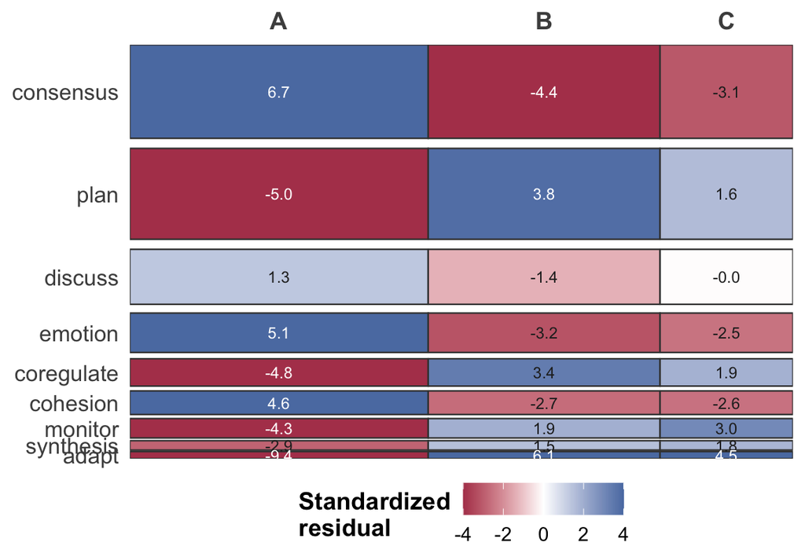

```r
plot_state_frequencies(nw_g, style = "mosaic", label = "all")
```

`consensus` is sharply over-represented in course A (residual ~+7) and sharply under-represented in B and C; `plan` shows the opposite pattern. The reading rule: any cell darker than ±2 is statistically non-trivial under the chi-square independence model.

## Bar combinations

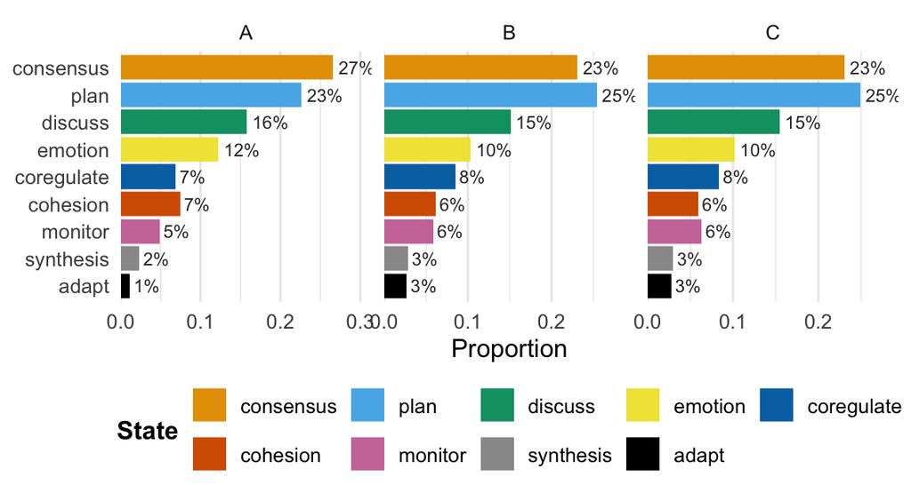

```r
plot_state_frequencies(nw_g, style = "bars")
```

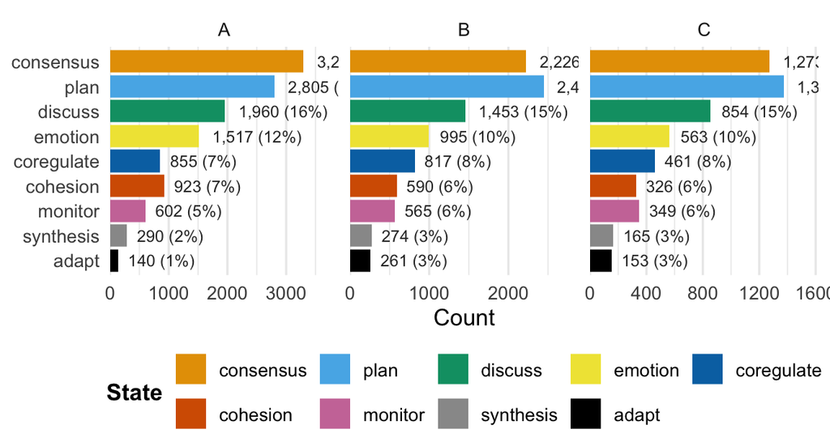

```r
plot_state_frequencies(nw_g, style = "bars", metric = "freq", label = "both")
```

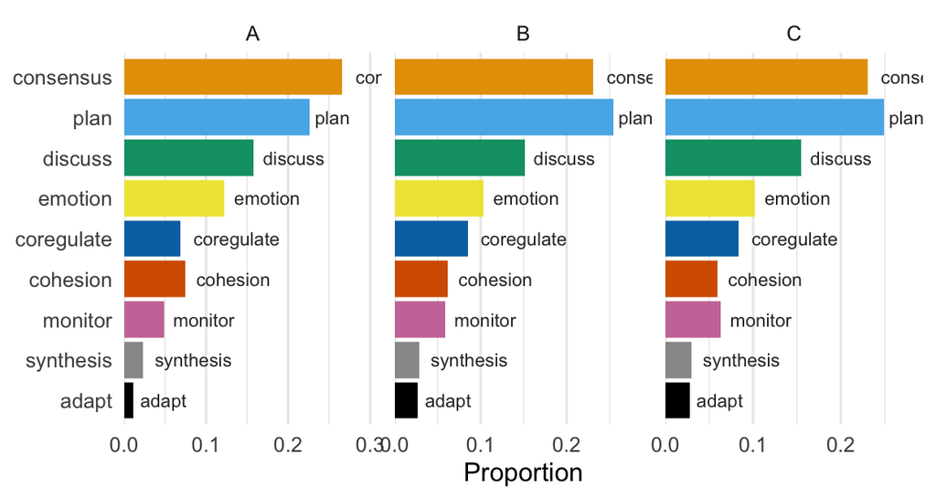

```r
plot_state_frequencies(nw_g, style = "bars", label = "state",
                       legend = "none")
```

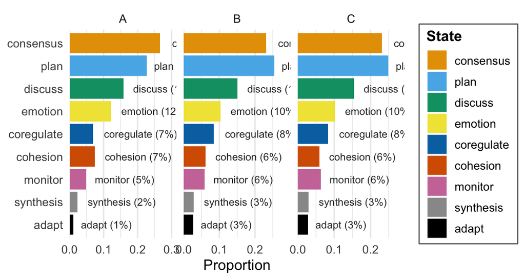

```r
plot_state_frequencies(nw_g, style = "bars", label = "all",
                       legend = "right", legend_frame = "border")
```